# Фазовые переходы

# 5. Фазовые переходы

Сосуществование фаз возможно только в том случае, если две фазы, находящиеся в тепловом, диффузионном и механическом контакте, находятся в равновесии:
$$T_1 = T_2, \quad \mu_1 = \mu_2, \quad P_1 = P_2.$$
В идеализированном случае фазой 1 является кварк-глюонная плазма, а фазой 2 — адронный газ. Фазы не сосуществуют на всей плоскости давления и температуры. Например, если
$$\mu_{\mathrm{QGP}} < \mu_{\mathrm{HG}},$$
устойчивой является плазменная фаза, тогда как при
$$\mu_{\mathrm{QGP}} > \mu_{\mathrm{HG}}$$
устойчивой оказывается адронная фаза.

Используя термодинамические величины, выраженные через большую статистическую сумму в предыдущем разделе, можно получить кривую сосуществования фаз — зависимость давления от температуры. Для малых отклонений давления и температуры от равновесных значений условие равенства химических потенциалов записывается в виде
$$\mu_1(P + dP, T + dT) = \mu_2(P + dP, T + dT).$$
Разлагая обе части в ряд, получаем
$$\mu_1(P,T) + \left(\frac{\partial \mu_1}{\partial P}\right)_T dP +
\left(\frac{\partial \mu_1}{\partial T}\right)_P dT
=
\mu_2(P,T) + \left(\frac{\partial \mu_2}{\partial P}\right)_T dP +
\left(\frac{\partial \mu_2}{\partial T}\right)_P dT.$$
Поскольку в равновесии
$$\mu_1(P,T) = \mu_2(P,T),$$
эти члены сокращаются, и можно выразить производную $dP/dT$:
$$\frac{dP}{dT}
=
\frac{\left(\frac{\partial \mu_2}{\partial T}\right)_P -
\left(\frac{\partial \mu_1}{\partial T}\right)_P}
{\left(\frac{\partial \mu_1}{\partial P}\right)_T - \left(\frac{\partial
\mu_2}{\partial P}\right)_T}.$$

Учитывая, что
$$G(N,P,T) = N \mu(P,T),$$
и используя стандартные термодинамические соотношения при постоянном числе частиц $N$, имеем
$$\left(\frac{\partial \mu}{\partial P}\right)_T = \frac{V}{N},\quad\quad
\left(\frac{\partial \mu}{\partial T}\right)_P = -\frac{S}{N}.$$
Хотя полное число частиц системы $N = N_1 + N_2$ остаётся постоянным, числа частиц в отдельных фазах изменяются при изменении объёма. В результате выражение для производной принимает вид
$$\frac{dP}{dT}
=
\frac{S_1/N_1 - S_2/N_2}{V_1/N_1 - V_2/N_2}.$$
Числитель представляет собой изменение энтропии при переносе одной частицы из фазы 1 в фазу 2, а знаменатель — соответствующее изменение объёма. Несмотря на то что $\frac{dP}{dT} \neq 0,$ обе фазы продолжают сосуществовать.

Умножая числитель на температуру, можно связать его с количеством теплоты, необходимым для переноса одной частицы между фазами. Эта величина
$$L = T\left(\frac{S_1}{N_1} - \frac{S_2}{N_2}\right)$$
называется **скрытой теплотой системы**. Скрытая теплота является мерой разности энтропий двух фаз. Фазовые переходы первого рода характеризуются ненулевой скрытой теплотой.

#### Физический смысл скрытой теплоты

**Скрытая теплота** — это количество энергии, которое необходимо передать системе (или отвести от неё) **для перевода вещества из одной фазы в другую при постоянной температуре и давлении, не изменяя при этом температуру системы.**

Ключевая идея:  
При фазовом переходе первого рода энергия не идёт на нагрев, а расходуется на **перестройку микроскопического состояния вещества**.

##### Интуитивная формулировка

> **Скрытая теплота — это энергия, которую система «прячет» в изменении своей фазы, не повышая температуру.**

Классический пример — кипение воды:

- температура остаётся равной $T = 100^\circ\mathrm{C}$,
- подводимая энергия идёт на разрыв межмолекулярных связей,
- энтропия и объём скачкообразно изменяются.

##### Почему скрытая теплота связана с энтропией

В термодинамике тепло, подводимое к системе в квазистатическом процессе, связано с изменением энтропии:
$$\delta Q = T\, dS$$
При фазовом переходе:

- температура $T$ постоянна,
- давление постоянно,
- изменяется фаза, а значит — **энтропия системы**.

Если рассматривать перенос **одной частицы** из фазы 1 в фазу 2, то изменение энтропии равно
$$\Delta
s = \frac{S_1}{N_1} - \frac{S_2}{N_2}$$
Следовательно, количество теплоты, необходимое для такого переноса при температуре $T$, равно
$$\delta q = T\,\Delta s$$
Именно это и есть **скрытая теплота на одну частицу**.

Почему выражение $L = T\left(\frac{S_1}{N_1} - \frac{S_2}{N_2}\right)$ является скрытой теплотой?

Это выражение:

1. **Пропорционально температуре**, как и любое обратимое тепловое превращение.
2. **Равно теплоте, необходимой для изменения фазы**, а не температуры.
3. **Характеризует скачок энтропии** между фазами — главный признак фазового перехода первого рода.
4. **Не зависит от пути процесса**, а только от свойств фаз.

Физически:

- $\frac{S}{N}$ — энтропия на одну частицу,
- разность $\frac{S_1}{N_1} - \frac{S_2}{N_2}$ показывает, насколько «более беспорядочной» является одна фаза по сравнению с другой,
- умножение на $T$ переводит этот энтропийный скачок в энергетическую величину.

##### Связь со скачками термодинамических величин

Фазовый переход первого рода характеризуется: - скачком энтропии $\Delta S \neq 0$, - скачком объёма $\Delta V \neq 0$, - ненулевой скрытой теплотой $L \neq 0$.

Для фазовых переходов второго рода: $\Delta S = 0 \quad \Rightarrow \quad L = 0$

поэтому скрытая теплота отсутствует.

# 6. Теория Фазовых переходов Ландау

#### Теория Ландау. Введение

**Фазовые переходы были систематически описаны Ландау в рамках теории среднего поля.**

Известно, что при постоянных температуре и объёме свободная энергия в состоянии равновесия принимает минимальное значение. Однако существует несколько переменных, по отношению к которым может проводиться минимизация. Вместо рассмотрения множества возможных переменных Ландау предположил, что система может быть охарактеризована одной величиной $\xi$, называемой **параметром порядка**. **В тепловом равновесии $\xi = \xi_0(T)$, где $\xi_0(T)$ — значение параметра порядка, минимизирующее свободную энергию.**

Ограничиваясь случаем $\mu = 0$, введём **свободную энергию Ландау** $F_L$, определяемую как
$$F_L(\xi, T) \equiv E(\xi, T) - T S(\xi, T).$$
При $\xi = \xi_0$, то есть в равновесии, свободная энергия Ландау достигает минимума и равна термодинамической свободной энергии $F(T)$:
$$F(T) = F_L(\xi_0, T) \le F_L(\xi, T).$$

При фиксированной температуре свободная энергия Ландау может иметь более одного минимума по $\xi$. Наименьший из них соответствует равновесному состоянию. В дальнейшем будем рассматривать случай, когда $F_L$ является чётной функцией $\xi$ и может быть разложена в ряд по степеням $\xi^{2n}$. Температурная зависимость содержится в коэффициентах разложения, так что
$$F_L(\xi, T) = g_0(T) + \frac{1}{2}g_2(T)\xi^2 + \frac{1}{4}g_4(T)\xi^4 +
\frac{1}{6}g_6(T)\xi^6 + \cdots .$$

#### Почему свободная функция Ландау симметрична по $\xi$

*Предположение о том, что свободная энергия Ландау является чётной функцией параметра порядка $\xi$, имеет физическое и симметрийное обоснование.*

Параметр порядка $\xi$ вводится как величина, характеризующая различие между фазами системы. Он обращается в нуль в симметричной, высокотемпературной фазе и становится ненулевым при фазовом переходе, сопровождающемся спонтанным нарушением симметрии.

**Основной принцип теории Ландау состоит в том, что свободная энергия должна быть инвариантна относительно всех симметрий микроскопического гамильтониана системы**. Если система симметрична относительно преобразования
$$\xi \rightarrow -\xi,$$
то термодинамический потенциал обязан удовлетворять условию
$$F_L(\xi, T) = F_L(-\xi, T).$$
Это условие непосредственно означает, что свободная энергия Ландау является чётной функцией параметра порядка.

Физически преобразование $\xi \rightarrow -\xi$ соответствует переходу между двумя эквивалентными упорядоченными состояниями системы. Например, в ферромагнетике параметр порядка отождествляется с намагниченностью. Состояния с $\xi = +M$ и $\xi = -M$ являются физически эквивалентными при отсутствии внешнего магнитного поля. Следовательно, свободная энергия не может зависеть от знака параметра порядка.

Если бы в разложении свободной энергии присутствовали нечётные степени $\xi$, например члены вида
$$F_L \sim \xi \quad \text{или} \quad F_L \sim \xi^3,$$
это означало бы предпочтение одного из знаков параметра порядка и, тем самым, явное нарушение симметрии системы, что противоречит исходным предположениям.

Следует подчеркнуть, что чётность свободной энергии по $\xi$ не является универсальным свойством, а является следствием симметрии системы. При наличии внешнего поля $h$, сопряжённого с параметром порядка, симметрия $\xi \rightarrow -\xi$ нарушается, и свободная энергия приобретает вид
$$F_L(\xi, T) = F_0 + a\xi^2 + b\xi^4 - h\xi.$$
В этом случае появляются нечётные по $\xi$ члены, а фазовый переход второго рода, как правило, сглаживается и переходит в кроссовер.

С точки зрения теории поля параметр порядка трансформируется по некоторому представлению группы симметрии, а свободная энергия должна быть скаляром, инвариантным относительно всех преобразований этой группы. Если $\xi$ меняет знак при симметрийном преобразовании, то инвариантные скалярные комбинации могут содержать только чётные степени $\xi$.

#### Изучение свободной энергии Ландау

Наиболее простой фазовый переход возникает в случае, когда, пренебрегая членами более высокого порядка, второй коэффициент $g_2$ меняет знак при $T = T_0$. Если $g_2$ является линейной функцией температуры, его можно схематически записать в виде $A(T - T_0)$, так что изменение знака при $T = T_0$ становится очевидным. Предполагается, что $g_4$ является постоянной величиной, а все последующие члены разложения пренебрежимо малы. Такие упрощающие предположения справедливы лишь в ограниченном интервале температур. Тогда
$$F_L(\xi, T) = g_0(T) + \frac{1}{2}A(T - T_0)\xi^2 + \frac{1}{4}g_4\xi^4.$$
Минимум свободной энергии Ландау по отношению к $\xi$ определяется условием
$$\left(\frac{\partial F_L}{\partial \xi}\right)_T
=
A(T - T_0)\xi + g_4\xi^3 = 0.$$
Это условие выполняется
$$\text{либо при} \quad \xi = 0, \quad \text{либо при}\quad \xi_{\min}^2 =
-\frac{A}{g_4}(T - T_0)$$
Если $A$ и $g_4$ оба положительны, то $\xi = 0$ является минимумом при $T > T_0$, и в этом случае
$$F(T) = g_0(T).$$
Второе решение соответствует минимуму свободной энергии Ландау при $T < T_0$. Заметим, что
$$\xi^2 \to 0 \quad \text{при} \quad T \to T_0 \ \text{снизу}.$$

Подставляя выражение для $\xi^2$ в свободную энергию Ландау, получаем
$$F_L(\xi_{\min}^2, T) = F(T)
= g_0(T) - \frac{A^2}{2g_4}(T - T_0)^2 + \frac{g_4 A^2}{4g_4^2}(T_0 -
T)^2
= g_0(T) - \frac{A^2}{4g_4}(T_0 - T)^2.$$

Производная свободной энергии по температуре равна
$$\frac{\partial F}{\partial T}
=
\frac{\partial g_0(T)}{\partial T}
+ \frac{A^2}{2g_4}(T_0 - T).$$
При $T = T_0$ эта производная не равна нулю, однако является непрерывной. Следовательно, данный фазовый переход относится ко второму роду, или является непрерывным, и скрытая теплота при таком переходе отсутствует. К таким переходам относятся, например, переходы в ферромагнетиках и сверхпроводниках.

Схематическое изображение зависимости $F_L(\xi^2, T)$ от $\xi^2$ для трёх различных температур $T > T_0$, $T = T_0$ и $T < T_0$ приведено на рис. 1. Значения $\xi^2$, минимизирующие $F_L$, показаны стрелками. Видно, что при $T \to T_0$ снизу равновесное значение $\xi_0^2$ смещается влево и совпадает с $\xi^2 = 0$ при $T = T_0$. Таким образом, равновесное значение $\xi^2$ тем больше, чем ниже температура относительно $T_0$.

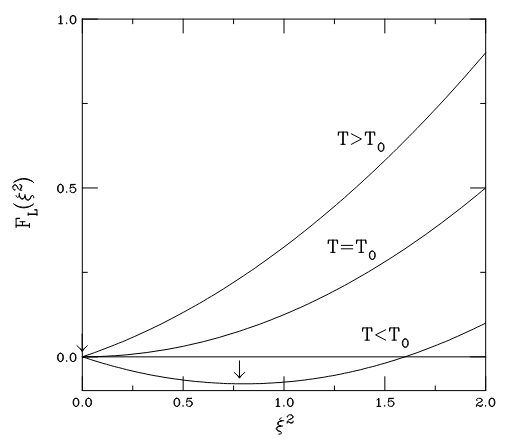

#### Описание фазового перехода 1 рода в теории Ландау. Отрицательный $g_4$, положительный $g_6$

Свободная энергия Ландау в этом случае имеет вид
$$F_L(\xi, T)
=
g_0(T)
+ \frac{A}{2}(T - T_0)\xi^2
- \frac{1}{4}|g_4(T)|\xi^4
+ \frac{1}{6}g_6\xi^6.$$

##### Почему такие знаки?

Коэффициент $g_2$ определяет устойчивость симметричной фазы с $\xi = 0$. При $g_2 > 0$ минимум свободной энергии расположен в точке $\xi = 0$, тогда как при $g_2 < 0$ минимум смещается к ненулевым значениям параметра порядка.

Коэффициент $g_4$ отвечает за форму свободной энергии при конечных значениях $\xi$ и играет ключевую роль в определении типа фазового перехода.

В случае $g_4 > 0,$ свободная энергия возрастает при увеличении $|\xi|$, и при изменении знака $g_2$ минимум свободной энергии смещается от нуля непрерывно. Это приводит к *фазовому переходу второго рода*, при котором параметр порядка возникает плавно.

Если же $g_4 < 0,$ вклад члена $- |g_4| \xi^4$ понижает свободную энергию при конечных значениях параметра порядка. В результате возникает конкуренция между стабилизирующим вкладом квадратичного члена и дестабилизирующим вкладом четвёртой степени параметра порядка.

При отрицательном $g_4$ свободная энергия без учёта высших степеней была бы неограниченно убывающей при больших $|\xi|$:
$$F_L(\xi) \to -\infty \quad \text{при} \quad |\xi| \to \infty.$$
Поэтому для физической устойчивости системы необходимо наличие положительного коэффициента $g_6 > 0,$ который стабилизирует свободную энергию при больших значениях параметра порядка и обеспечивает существование глобального минимума.

В ситуации, когда
$$g_4 < 0 \quad \text{и} \quad g_6 > 0,$$
при высоких температурах свободная энергия имеет единственный минимум при $\xi = 0$. При понижении температуры появляется второй минимум при конечном значении $\xi \neq 0$. При некоторой температуре $T_c$ значения свободной энергии в двух минимумах совпадают:
$$F_L(\xi = 0, T_c) = F_L(\xi \neq 0, T_c).$$
В этой точке система скачкообразно переходит из симметричной фазы в упорядоченную фазу, что соответствует *фазовому переходу первого рода*.

Такое поведение можно увидеть на рис. 2.

Поскольку параметр порядка при таком переходе изменяется скачком,
$$\Delta \xi \neq 0,$$
энтропия системы также испытывает разрыв:
$$\Delta S = -\frac{\partial F}{\partial T} \neq 0.$$
Следовательно, фазовый переход сопровождается ненулевой скрытой теплотой
$$L = T \Delta S \neq 0.$$

#### Изучение свободной энергии Ландау в случае фазового перехода 1 рода

Итак, свободная энергия Ландау в этом случае имеет вид
$$F_L(\xi, T)
=
g_0(T)
+ \frac{A}{2}(T - T_0)\xi^2
- \frac{1}{4}|g_4(T)|\xi^4
+ \frac{1}{6}g_6\xi^6.$$
Для нахождения минимумов свободной энергии Ландау возьмём производную по $\xi$:
$$\frac{\partial F_L}{\partial \xi}
=
A(T - T_0)\xi
- |g_4(T)|\xi^3
+ g_6\xi^5
= 0.$$
Как и ранее, одно из решений соответствует
$$\xi = 0,$$
в то время как другое решение определяется уравнением
$$A(T - T_0) - |g_4(T)|\xi^2 + g_6\xi^4 = 0,$$
которое имеет корень
$$\xi^2
=
\frac{|g_4(T)| \pm \sqrt{|g_4(T)|^2 - 4A g_6 (T - T_0)}}{2A(T - T_0)}.$$
В этом случае значения свободной энергии при $\xi = 0$ и при $\xi \neq 0$ становятся равными при некотором значении температуры $T \neq T_0$. Это значение температуры и является критической температурой $T_c$. Поскольку
$$T_c \neq T_0,$$
величина $\xi^2$ не стремится к нулю непрерывно при $T = T_c$. Таким образом, данный фазовый переход является фазовым переходом первого рода и сопровождается наличием скрытой теплоты.

На рис. 2. показана свободная энергия Ландау $F_L$ как функция $\xi^2$ для различных значений температуры. При $T > T_c$, где $T_c$ — критическая температура, единственный минимум свободной энергии Ландау соответствует
$$\xi^2 = 0.$$
При $T = T_c$, напротив, существуют два равных минимума:
$$F_L(\xi^2 = 0, T = T_c)
=
F_L(\xi^2 = \xi_0^2, T = T_c).$$
Ниже $T_c$ остаётся лишь один минимум, соответствующий конечному значению $\xi_0^2$. По мере понижения температуры ниже $T_c$ значение $\xi_0^2$ возрастает.

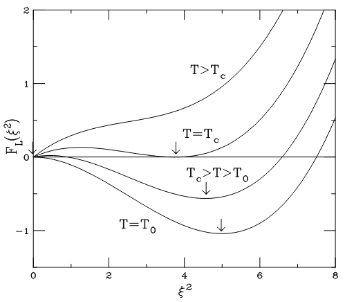

# 7. Фазовые переходы в ядерной физике

В этом разделе мы вычислим статсумму квантово-механической системы:
$$Z
=
\sum_a
\langle a | \exp\!\left[-\frac{1}{T}(\hat H - \mu \hat N)\right] | a
\rangle \equiv
\mathrm{Tr}\,
\exp\!\left[-\frac{1}{T}(\hat H - \mu \hat N)\right]$$
для трёх случаев: двух предельных предположений, а также одного более реалистичного. В первом случае мы пренебрегаем массами частиц и предполагаем высокую температуру, как, например, в области центральных быстрот при высокоэнергетических столкновениях тяжёлых ионов.

Второй случай соответствует пределу $T \to 0,$ когда единственными существенными степенями свободы являются массивные нуклоны, как это может иметь место в ядре нейтронной звезды.

Наконец, мы рассматриваем более реалистичный пример конечной температуры и конечной массы частиц.

Обобщённое выражение для $\ln Z$ для частиц и античастиц, как бозонов, так и фермионов, имеет вид
$$\boxed{\ln Z(T,\mu,V)
=
\frac{gV}{2\pi^2 T}
\int_0^\infty dk \, \frac{k^4}{3E}
\left[
\frac{1}{\exp[(E-\mu)/T]\mp 1}
+
\frac{1}{\exp[(E+\mu)/T]\mp 1}
\right]}$$

Последовательно разберем каждый член в этом выражении

##### Фактор вырождения $g$

*Фактор вырождения $g$ учитывает число внутренних квантовых состояний частицы, которые имеют одну и ту же энергию*. Это означает, что при фиксированном импульсе $\vec{k}$ существует $g$ различных независимых состояний.

Фактор $g$ просто умножается на статсумму, поскольку каждое из этих состояний вносит одинаковый вклад.

##### Типичные вклады в $g$:

- спин: для спина $s$ имеется $2s+1$ состояний;
- цвет: например, для кварков $N_c = 3$;
- изоспин или другие внутренние квантовые числа.

Например, для фермиона со спином $1/2$ без цвета: $g = 2$

##### Плотность состояний в $k$-пространстве и граничные условия

Физический смысл граничных условий

При вычислении статистической суммы необходимо задать граничные условия для волновых функций частиц. Рассмотрим систему в конечном объёме
$$V = L_x L_y L_z.$$
Наиболее удобным и физически оправданным выбором являются периодические граничные условия:
$$\psi(x + L_x, y, z) = \psi(x, y, z),$$
и аналогично для направлений $y$ и $z$.

Физический смысл этих условий состоит в следующем: - система моделируется как часть бесконечной среды без границ; - обеспечивается трансляционная инвариантность системы.

В пределе
$$V \to \infty$$
выбор граничных условий не влияет на физические термодинамические величины, однако периодические условия существенно упрощают математический аппарат.

##### Квантование импульса

При периодических граничных условиях волновая функция имеет вид плоской волны:
$$\psi(x) \sim e^{i k_x x}.$$

Из условия периодичности следует:
$$e^{i k_x (x + L_x)} = e^{i k_x x}
\quad \Rightarrow \quad
k_x L_x = 2\pi K_x,
\quad
K_x \in \mathbb{Z}.$$

Аналогично:
$$k_y = \frac{2\pi}{L_y} K_y,
\qquad
k_z = \frac{2\pi}{L_z} K_z.$$

Таким образом, допустимые значения импульса образуют равномерную трёхмерную решётку в $k$-пространстве.

##### Объём, соответствующий одному квантовому состоянию

Расстояние между соседними разрешёнными значениями компонент импульса равно:
$$\Delta k_x = \frac{2\pi}{L_x}, \quad
\Delta k_y = \frac{2\pi}{L_y}, \quad
\Delta k_z = \frac{2\pi}{L_z}.$$
Следовательно, одному квантовому состоянию соответствует элемент объёма в $k$-пространстве:
$$\Delta^3 k
=
\Delta k_x \Delta k_y \Delta k_z
=
\frac{(2\pi)^3}{L_x L_y L_z}
=
\frac{(2\pi)^3}{V}.$$

##### Плотность состояний в $k$-пространстве

Плотность состояний определяется как число квантовых состояний на единицу объёма в $k$-пространстве. Она равна обратной величине элементарного объёма, приходящегося на одно состояние:
$$\rho(k)
=
\frac{1}{\Delta^3 k}
=
\frac{V}{(2\pi)^3}.$$
Это означает, что в элементе объёма $d^3k$ содержится
$$\frac{V}{(2\pi)^3} \, d^3k$$
квантовых состояний.

##### Переход от суммы к интегралу

В термодинамическом пределе расстояние между разрешёнными значениями импульса становится бесконечно малым, и сумма по дискретным состояниям может быть заменена интегралом:
$$\sum_{\vec{k}}
\;\longrightarrow\;
\frac{V}{(2\pi)^3}
\int d^3k.$$
С учётом вырождения получаем
$$\ln Z(T,\mu)
=
g \frac{V}{(2\pi)^3}
\int d^3 k \, \ln Z(E;T,\mu).$$

##### Учет античастиц

Античастицы имеют ту же энергию $E$, но противоположный химический потенциал $-\mu$. Поэтому полный логарифм статистической суммы:
$$\ln Z(T,\mu)
=
g \frac{V}{(2\pi)^3}
\int d^3 k
\left[
\ln Z(E;T,\mu)
+
\ln Z(E;T,-\mu)
\right].$$

##### Переход к сферическим координатам

Поскольку энергия зависит только от модуля импульса,
$$E = \sqrt{k^2 + m^2},$$
Поскольку статистическая сумма зависит только от модуля импульса $k$, а не от его углового распределения, имеем
$$d^3k = 4\pi k^2 dk.$$
Отсюда
$$\ln Z(T,\mu)
=
\frac{gV}{2\pi^2}
\int_0^\infty dk\, k^2
\left[
\ln Z(E;T,\mu)
+
\ln Z(E;T,-\mu)
\right].$$

##### Замена переменной $k \to E$

Используем связь
$$E^2 = k^2 + m^2,
\quad
k\,dk = E\,dE.$$
Тогда
$$k^2 dk = k E dE.$$
Интеграл принимает вид
$$\ln Z(T,\mu)
=
\frac{gV}{2\pi^2}
\int dE\, k E
\left[
\ln Z(E;T,\mu)
+
\ln Z(E;T,-\mu)
\right].$$

##### Интегрирование по частям

Рассмотрим вклад частиц:
$$I = \int_0^\infty dE\, k E \ln Z(E;T,\mu).$$
Пишем
$$kE = \frac{d}{dE}\left(\frac{k^3}{3}\right),
\quad
k = \sqrt{E^2 - m^2}.$$
Интегрируем по частям:
$$I =
\left.
\frac{k^3}{3} \ln Z
\right|_0^\infty
-
\int_0^\infty \frac{k^3}{3}
\frac{d}{dE} \ln Z \, dE.$$

##### Почему граничный член равен нулю

- При $E \to \infty$: $\ln Z \sim e^{-E/T} \to 0$ быстрее любой степени $E$.
- При $E = m$: $k = 0 \Rightarrow k^3 = 0$

Следовательно,
$$\left.
\frac{k^3}{3} \ln Z
\right|_0^\infty
= 0.$$

##### Производная $\ln Z$

Для бозонов и фермионов:
$$\ln Z(E;T,\mu)
=
\mp \ln\left(1 \mp e^{-(E-\mu)/T}\right).$$
Отсюда
$$\frac{d}{dE} \ln Z
=
\frac{1}{T}
\frac{1}{\exp[(E-\mu)/T] \mp 1}.$$
Подставляя, получаем
$$\ln Z(T,\mu)
=
\frac{gV}{2\pi^2 T}
\int_0^\infty dk
\frac{k^4}{3E}
\frac{1}{\exp[(E-\mu)/T]\mp 1}.$$

Добавляя вклад античастиц, получаем окончательное выражение

Обобщённое выражение для $\ln Z$ для частиц и античастиц, как бозонов, так и фермионов, имеет вид
$$\ln Z(T,\mu,V)
=
\frac{gV}{2\pi^2 T}
\int_0^\infty dk \, \frac{k^4}{3E}
\left[
\frac{1}{\exp[(E-\mu)/T]\mp 1}
+
\frac{1}{\exp[(E+\mu)/T]\mp 1}
\right]$$

#### Свободная энергия $F$

*Disclamer: в данном разделе нужно быть очень аккуратным. Для $F$ используются разные интегральные формулы, которые похожи, но не во всем. Например, в каком-то есть $T$ в знаменателе нормировочного множителя, а в каком-то нет*

Наиболее удобная форма свободной энергии для вычисления термодинамических величин $\epsilon$, $P$, $n$ и $s$ получается при использовании статистической суммы в виде
$$F
=
- T \ln Z(T,\mu)
=
- g V T
\int \frac{d^3k}{2\pi^2}
\left[
\ln Z(E;T,\mu) + \ln Z(E;T,-\mu)
\right]$$
Удобнее переписать свободную энергию через функции распределения
$$f(E;T,\mu)
=
\frac{1}{\exp[(E-\mu)/T]\mp 1},$$
$$f(E;T,-\mu)
=
\frac{1}{\exp[(E+\mu)/T]\mp 1},$$
для античастиц.

Заметим, что
$$1 \pm f(E;T,\mu)
=
f'(E;T,\mu)
=
\frac{1}{1 \mp \exp[-(E-\mu)/T]},$$
где верхний знак соответствует бозонам, а нижний — фермионам. Тогда свободная энергия может быть также записана в виде
$$F
=
- g V
\int \frac{d^3k}{2\pi^2}
\left[
\ln f'(E;T,\mu) + \ln f'(E;T,-\mu)
\right].$$

#### Давление

Давление является наиболее простой величиной для вычисления, поскольку
$$P = -\frac{\partial F}{\partial V}.$$
Используя выражение для $\ln Z(E;T,\mu)$, получаем
$$P
=
\frac{g}{2\pi^2}
\int_0^\infty dk
\frac{k^4}{3E}
\left[
f(E;T,\mu) + f(E;T,-\mu)
\right].$$
Здесь мы используем следующую формулу :
$$\ln Z(T,\mu,V)
=
\frac{gV}{2\pi^2 T}
\int_0^\infty dk \, \frac{k^4}{3E}
\left[
\frac{1}{\exp[(E-\mu)/T]\mp 1}
+
\frac{1}{\exp[(E+\mu)/T]\mp 1}
\right]$$

#### Плотность числа частиц и химический потенциал

Теперь перейдём к вычислению плотности числа частиц. Следует отметить, что даже при
$$\mu = 0$$
плотность числа частиц не обязана обращаться в нуль и может быть достаточно большой.

Химический потенциал $\mu$ отвечает **не за существование частиц**, а за **асимметрию между частицами и античастицами**.

При $\mu = 0$: - частицы и античастицы рождаются термически, - их числа равны, - но каждое из них **ненулевое**.

Поэтому: - полная плотность частиц $\neq 0$, - чистая (разностная) плотность может быть равна нулю.

В термодинамике полное число частиц $N$ определяется как производная свободной энергии по химическому потенциалу:
$$N = -\frac{\partial F}{\partial \mu}.$$

Плотность числа частиц равна
$$n = \frac{N}{V}= -\frac{1}{V}\frac{\partial F}{\partial \mu}$$
Рассмотрим вклад только частиц в свободную энергию:
$$F_{\text{part}}
=
-
\frac{gV}{2\pi^2}
\int_0^\infty dk\, k^2
\ln\!\left(1 \mp e^{-(E-\mu)/T}\right).$$
Беря производную по химическому потенциалу, получаем
$$-\frac{1}{V}\frac{\partial F_{\text{part}}}{\partial \mu}
=
\frac{g}{2\pi^2}
\int_0^\infty dk\, k^2
\frac{\partial}{\partial \mu}
\ln\!\left(1 \mp e^{-(E-\mu)/T}\right).$$
$$\frac{\partial}{\partial \mu}
\ln\!\left(1 \mp e^{-(E-\mu)/T}\right)
=
\frac{1}{T}
\frac{1}{\exp[(E-\mu)/T]\mp 1},$$
Вспоминаем, что это просто функция распределения
$$f(E;T,\mu)
=
\frac{1}{\exp[(E-\mu)/T]\mp 1}.$$
В результате плотность числа частиц равна
$$n
=
g
\int \frac{dk\,k^2}{2\pi^2}
f(E;T,\mu).$$

##### Античастицы

Античастицы имеют тот же спектр энергий, но противоположный химический потенциал $-\mu$. Их вклад в плотность числа частиц равен
$$n_{\bar p}
=
g
\int \frac{dk\,k^2}{2\pi^2}
f(E;T,-\mu).$$
Поскольку частицы и античастицы несут противоположный барионный заряд, чистая плотность частиц определяется разностью:
$$n_{\mathrm{net}}
=
n - n_{\bar p}
=
g
\int \frac{dk\,k^2}{2\pi^2}
\left[
f(E;T,\mu) - f(E;T,-\mu)
\right].$$

При $\mu = 0$ вклад частиц и античастиц одинаков, и чистая плотность обращается в нуль,
$$n_{\mathrm{net}} = 0,$$
хотя суммарная плотность частиц и античастиц остаётся конечной. **Ненулевая чистая плотность соответствует наличию барионной асимметрии в системе.**

#### Плотность энергии

Теперь вычислим плотность энергии $\epsilon$. В большом каноническом ансамбле она выражается через свободную энергию и плотность числа частиц как
$$\epsilon
=
- g T^2 \frac{\partial}{\partial T}\!\left(\frac{F}{T}\right)
+ \mu n.$$

Используя выражение для свободной энергии через статистическую сумму, получаем
$$\epsilon
=
g T^2
\int \frac{dE\, k E}{2\pi^2}
\frac{\partial}{\partial T}
\left[
\ln f'(E;T,\mu) + \ln f'(E;T,-\mu)
\right]
+
g
\int \frac{dE\, k E}{2\pi^2}
\left[
\mu f(E;T,\mu) - \mu f(E;T,-\mu)
\right].$$

Переходя к явному виду производных, имеем
$$\epsilon
=
g
\int \frac{dE\, k E}{2\pi^2}
\Big[
(E-\mu) f(E;T,\mu)
+
(E+\mu) f(E;T,-\mu)
+
\mu f(E;T,\mu)
-
\mu f(E;T,-\mu)
\Big].$$

Члены, пропорциональные $\mu$, взаимно сокращаются, и окончательно получаем
$$\epsilon
=
g
\int \frac{dk\, k^2}{2\pi^2}
E
\left[
f(E;T,\mu) + f(E;T,-\mu)
\right].$$

Для безмассовых частиц, $E = k$, из выражений для давления и плотности энергии следует соотношение
$$\epsilon = 3P.$$

#### Плотность энтропии

Вычисление плотности энтропии несколько более громоздко. Для простоты рассмотрим вклад только частиц; вклад античастиц получается аналогично при замене $\mu \to -\mu$.

Из определения
$$1 \pm
f(E;T,\mu)=f'(E;T,\mu)=\frac{1}{1 \mp \exp[-(E-\mu)/T]}$$
следует тождество
$$f'(E;T,\mu) \mp f(E;T,\mu) = 1.$$
Связь между функциями $f$ и $f'$ имеет вид
$$f(E;T,\mu)
=
e^{-(E-\mu)/T}
f'(E;T,\mu).$$

Плотность энтропии определяется как
$$s
=
-\frac{\partial (T \ln Z)}{\partial T}.$$

Используя выражение для статсуммы, получаем
$$s
=
g
\int \frac{dk\, k^2}{2\pi^2}
\left[
\ln f'(E;T,\mu)
-
f(E;T,\mu)\frac{E-\mu}{T}
\right].$$

$$F
=
- g V
\int \frac{d^3k}{2\pi^2}
\left[
\ln f'(E;T,\mu) + \ln f'(E;T,-\mu)
\right].$$

Умножая первый член на единицу в виде
$$f'(E;T,\mu) \mp f(E;T,\mu),$$
получаем
$$s
=
g
\int \frac{dk\, k^2}{2\pi^2}
\left[
f'(E;T,\mu)\ln f'(E;T,\mu)
\mp
f(E;T,\mu)\ln f'(E;T,\mu)
-
f(E;T,\mu)\frac{E-\mu}{T}
\right].$$

Из соотношения
$$\ln f(E;T,\mu)
=
\ln f'(E;T,\mu)
-
\frac{E-\mu}{T}$$
следует окончательное выражение для плотности энтропии частиц:
$$s
=
g
\int \frac{dk\, k^2}{2\pi^2}
\left[
f'(E;T,\mu)\ln f'(E;T,\mu)
\mp
f(E;T,\mu)\ln f(E;T,\mu)
\right].$$
Это уже **каноническая форма энтропии квантового газа**: - первый член — вклад «свободных состояний»; - второй — вклад реально занятых уровней; - знак $\mp$ различает фермионы и бозоны.

Формула, к которой мы пришли, — это **квантово-статистическое обобщение формулы Больцмана–Гиббса**

Выражение для плотности энтропии античастиц имеет тот же вид с заменой $\mu \to -\mu$.